# Supplementary information for: A flexible modelling framework for estimating thermal sensitivity across life

Authors

Affiliations

Daniel W.A. Noble

Division of Ecology and Evolution, Research School of Biology, Australian National University

Pieter A. Arnold

Division of Ecology and Evolution, Research School of Biology, Australian National University

Patrice Pottier

Department of Biological and Environmental Sciences, University of Gothenburg

Published

May 5, 2026

# 1 A Tutorial with Simulations

This section is a guided tutorial using simulated data. We show, step by step, how the Bayesian hierarchical 4PL — under both binomial sampling and the more realistic beta-binomial (overdispersed) case – can recover thermal sensitivity ($z$) and $CT_{max_{1hr}}$ from the single joint model, yet provide substantial downstream benefits in terms of propagating uncertainty and giving more flexibility. We then complement the simulation with a few case studies which walk through real data that is presented within the main manuscript in other sections.

### 1.0.1 Simulating Data

#### 1.0.1.1 Step 1 — Pick realistic, biologically meaningful parameters

We choose values typical of a thermal mortality assay. The four 4PL parameters are the lower and upper asymptotes ($\ell, u$), the slope on the $\log_{10}$-time axis ($k$), and a midpoint that varies linearly with temperature: $\text{mid}(T) = \beta_0 + \beta_1(T - \bar T)$. Each value below has a clear biological reading.

```r
true_params <- list(
  ell      = 0.03,   # 3% of individuals survive even at the longest exposures
  u        = 0.97,   # 97% are alive at very short exposures
  k        = 8,      # steepness of the survival drop on the log10(t) axis
  m_beta0  = 1.5,    # midpoint at the grand-mean temperature: ~31.6 min
  m_beta1  = -0.15,  # midpoint drops 0.15 log10-min per °C; z = -1/beta1 ≈ 6.7 °C
  T_bar    = 34      # grand-mean temperature
)
```

The implied thermal sensitivity is $z = -1/\beta_1 \approx 6.7$°C — the temperature change that shifts LT50 by a factor of 10. From the same parameters we can also compute the simulation truth for the uncentred TDT intercept $\alpha = \beta_0 + \tfrac{1}{k}\log\tfrac{u - 0.5}{0.5 - \ell} - \beta_1\bar{T}$ and the critical thermal limit at 1 hour $CT_{max_{1hr}} = (\log_{10} 60 - \alpha)/\beta_1$ — both pipelines below will be checked against these known values.

```r
true_z      <- -1 / true_params$m_beta1
true_alpha  <- true_params$m_beta0 +
  (1 / true_params$k) *
  log((true_params$u - 0.5) / (0.5 - true_params$ell)) -
  true_params$m_beta1 * true_params$T_bar
true_CTmax  <- (log10(60) - true_alpha) / true_params$m_beta1
```

#### 1.0.1.2 Step 2 — Lay out a factorial assay design

We mimic a textbook TDT experiment: a grid of five assay temperatures crossed with six log-spaced exposure durations, repeated 30 times per cell, with 30 individuals tested per replicate. That gives 900 trials and 27,000 individuals — large enough to recover the parameters with negligible posterior uncertainty, but small enough to fit in a few minutes. Of course, in practice we will not have this much data as will be seen in the case studies, but simulations are a good starting point to understand the models being fit and the conversions.

```r
temps     <- c(30, 32, 34, 36, 38)             # 5 assay temperatures (°C)
durations <- c(1, 5, 15, 45, 135, 405)         # 6 durations (minutes, log-spaced)
n_rep     <- 30                                # 30 replicates per cell
n_per_rep <- 30                                # 30 individuals per replicate

design <- tidyr::expand_grid(
  T   = temps,
  t   = durations,
  rep = seq_len(n_rep)
) |>
  dplyr::mutate(
    log10_t = log10(t),
    T_c     = T - true_params$T_bar,                        # mean-centred T
    mid     = true_params$m_beta0 + true_params$m_beta1 * T_c,  # mid(T)
    p_true  = true_params$ell +
      (true_params$u - true_params$ell) /
      (1 + exp(true_params$k * (log10_t - mid))),
    n = n_per_rep
  )
```

#### 1.0.1.3 Step 3 — Look at the truth before we fit anything

Before generating noisy data, let’s plot the *true* survival surface (Figure S 1) so we know what the model is being asked to recover. Each line is the 4PL at one assay temperature, plotted against $\log_{10}$ exposure time.

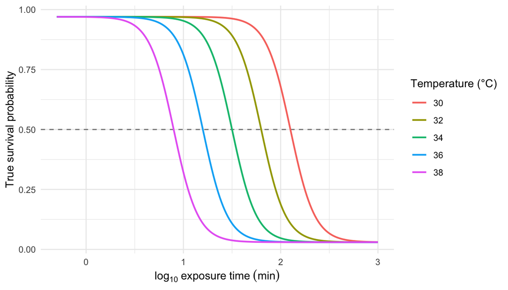

Figure 1: The known 4PL dose-response surface used to generate the simulated data, evaluated on a dense time grid at each of the five assay temperatures. The horizontal line marks 50% survival; where each curve crosses it gives the true LT50 at that temperature.

Notice the curves shift left as temperature rises: hotter temperatures kill faster, so the LT50 is reached at shorter durations. That horizontal shift in midpoints is exactly what $\beta_1$ encodes. This is the structure the model has to recover from noisy survival counts.

#### 1.0.1.4 Step 4 — Generate noisy data: binomial and beta-binomial

Real survival counts have at least two flavours of noise. **Binomial** sampling is the textbook case: each replicate’s survival count is a draw from $\text{Binomial}(n, p)$ with $p$ from the 4PL surface. **Beta-binomial** sampling adds *overdispersion* — replicate-to-replicate variability in $p$ that the binomial cannot capture, e.g., from cohort effects or unmodelled heterogeneity. Real TDT data almost always show overdispersion.

```r
# (a) Binomial: y ~ Binomial(n, p_true)
sim_bin <- design |>
  dplyr::mutate(y = rbinom(dplyr::n(), size = n, prob = p_true))

# (b) Beta-binomial: replicate-level p drawn from Beta(p*phi, (1-p)*phi)
phi <- 5  # smaller phi = more overdispersion
sim_bb <- design |>
  dplyr::mutate(
    p_draw = rbeta(dplyr::n(), p_true * phi, (1 - p_true) * phi),
    y      = rbinom(dplyr::n(), size = n, prob = p_draw)
  )
```

### 1.0.2 The classical two-stage TDT pipeline

We first run the simulated data through the **classical two-stage TDT pipeline** (Ørsted *et al.* 2022; Rezende *et al.* 2014), which is dominant in the thermal-tolerance literature.

1. **Stage 1.** At each assay temperature, fit a logistic dose-response curve to the count data and read off a point estimate of $\log_{10}\text{LT50}_T$.
2. **Stage 2.** Regress those Stage-1 point estimates on assay temperature with ordinary least squares, then derive $z = -1/\beta_1$ and $CT_{max_{1hr}} = (\log_{10} 60 - \alpha)/\beta_1$ from the fitted line.

#### 1.0.2.1 Stage 1 — per-temperature dose-response curves

We fit a binomial GLM with a logit link separately at each assay temperature. This is the most-common Stage-1 specification in the TDT literature: a two-parameter logistic with asymptotes constrained to 0% and 100%. The midpoint $\log_{10}\text{LT50}_T = -\beta_0/\beta_1$ falls out of the GLM’s two coefficients.

```r
fit_stage1 <- function(sim_data) {
  sim_data |>
    dplyr::group_by(T) |>
    dplyr::group_modify(function(d, key) {
      f  <- glm(cbind(y, n - y) ~ log10_t, data = d, family = binomial())
      co <- coef(f)
      tibble::tibble(log10_lt50 = as.numeric(-co[1] / co[2]))
    }) |>
    dplyr::ungroup()
}

stage1_bin <- fit_stage1(sim_bin)
stage1_bb  <- fit_stage1(sim_bb)
```

Table 1: Per-temperature Stage-1 estimates of $\log_{10}\text{LT50}$ from a binomial GLM with logit link, fit separately at each of the five assay temperatures. Truth values are the simulated midpoints (which coincide with $\log_{10}\text{LT50}$ here because the simulation asymptotes are near 0 and 1).

| T | truth_log10_lt50 | bin_log10_lt50 | bb_log10_lt50 |
| --- | --- | --- | --- |
| 30.000 | 2.100 | 2.061 | 2.082 |
| 32.000 | 1.800 | 1.795 | 1.800 |
| 34.000 | 1.500 | 1.480 | 1.528 |
| 36.000 | 1.200 | 1.202 | 1.195 |
| 38.000 | 0.900 | 0.907 | 0.954 |

With the simulation’s true asymptotes near 0 and 1, the 2PL’s forced-asymptote constraint introduces negligible bias here, so each Stage-1 estimate sits close to the simulation truth.

#### 1.0.2.2 Stage 2 — log-linear TDT regression

Stage 2 regresses Stage-1 $\log_{10}\text{LT50}$ on assay temperature with ordinary least squares. The classical TDT quantities — $z = -1/\beta_1$ and $CT_{max_{1hr}} = (\log_{10} 60 - \alpha)/\beta_1$ — fall out of the fitted line.

```r
fit_stage2 <- function(stage1) {
  fit2 <- lm(log10_lt50 ~ T, data = stage1)
  co   <- coef(fit2)

  tibble::tibble(
    quantity = c("z (°C)", "CTmax at 1 hr (°C)"),
    est      = c(as.numeric(-1 / co["T"]),
                 as.numeric((log10(60) - co["(Intercept)"]) / co["T"]))
  )
}

ts_bin <- fit_stage2(stage1_bin)
ts_bb  <- fit_stage2(stage1_bb)
```

Figure S 2 visualises the Stage-2 fit. Each point is one Stage-1 $\log_{10}\text{LT50}$ estimate from Table S 1; the solid line is the OLS regression through them. The slope is $\beta_1$, from which $z = -1/\beta_1$ — i.e., the temperature step that changes $\log_{10}\text{LT50}$ by one decade. The line’s height at $\log_{10} 60 \approx 1.78$ (1 hour) is at the temperature equal to $CT_{max_{1hr}}$ — the vertical dotted line drops from this intersection straight to the temperature axis to mark it. The dashed grey line is the simulation truth.

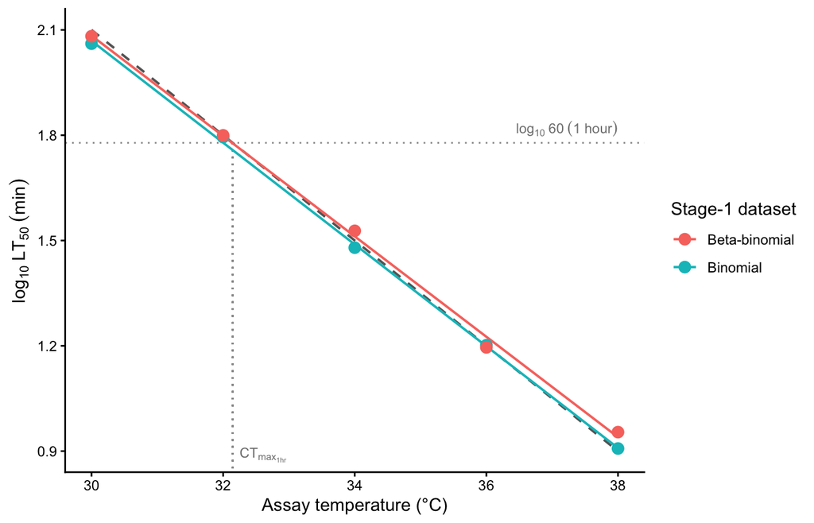

Figure 2: Stage-2 OLS regression of $\log_{10}\text{LT50}$ on assay temperature, fit separately to the binomial and beta-binomial simulated datasets. Points are the Stage-1 per-temperature LT50 estimates; solid coloured lines are the OLS fits; the dashed grey line is the simulation truth. The slope of each line equals $\beta_1$, from which $z = -1/\beta_1$. The horizontal dotted line marks $\log_{10} 60$ (1 hour); the vertical dotted line drops from where the truth crosses 1 hour straight down to the temperature axis, marking $CT_{max_{1hr}}$ visually.

This is the entire two-stage workflow. The point estimates that come out — $z$ and $CT_{max_{1hr}}$ — are what the field reports. We carry them forward (`ts_bin` and `ts_bb`) for the side-by-side comparison once we have the joint Bayesian results.

### 1.0.3 A joint Bayesian 4PL

Instead of fitting a separate logistic at each assay temperature and then regressing the LT50s, the joint fit estimates every parameter — $\ell$, $u$, $k$, $\beta_0$ and $\beta_1$ — in a single hierarchical model on the raw counts. We now use the same simulated data to derive the $z$ and $CT_{max_{1hr}}$ from the posterior, in one model rather than two.

#### 1.0.3.1 Specifying the 4PL in `brms`

The model has two pieces. The first is the 4PL itself — survival probability as a function of $\log_{10}$ exposure time:

$$p_{ij} \;=\; \ell \;+\; \frac{u - \ell}{1 + \exp\!\bigl(k\,(\log_{10} t_{ij} - \text{mid}_{ij})\bigr)},
\tag{1}$$

where $\ell$ and $u$ are the lower and upper asymptotes, $k$ is the slope on the $\log_{10} t$ axis, and $\text{mid}_{ij}$ is the value of $\log_{10} t$ at which the curve crosses the midpoint between $\ell$ and $u$. The second piece lets the midpoint vary linearly with mean-centred temperature:

$$\text{mid}_{ij} \;=\; \beta_0 + \beta_1\,(T_{ij} - \bar{T}),
\tag{2}$$

so that $\beta_1$ encodes how fast the dose-response curve shifts on the time axis as assay temperature changes; $\bar{T}$ is the grand-mean temperature, included so that $\beta_0$ is interpretable as the midpoint at the average assay temperature.

In `brms` non-linear syntax these two pieces become one formula and four sub-formulas — one for each parameter in the 4PL model:

```r
# Soft constraints to keep the parameters in their natural ranges.
# These are not informative priors — just the bounds the parameters
# must obey to be biologically meaningful.
priors_4pl <- c(
  prior(beta(1, 5),    nlpar = "ell", lb = 0, ub = 1),
  prior(beta(5, 1),    nlpar = "u",   lb = 0, ub = 1),
  prior(normal(0, 10), nlpar = "k",   lb = 0),
  prior(normal(0, 5),  nlpar = "mid")
)

bform_bin <- bf(
  y | trials(n) ~ ell + (u - ell) / (1 + exp(k * (log10_t - mid))),
  ell ~ 1, u ~ 1, k ~ 1, mid ~ T_c,
  nl = TRUE,
  family = binomial(link = "identity")
)

# Same model, beta-binomial likelihood for the overdispersed dataset.
bform_bb <- bf(
  y | trials(n) ~ ell + (u - ell) / (1 + exp(k * (log10_t - mid))),
  ell ~ 1, u ~ 1, k ~ 1, mid ~ T_c,
  nl = TRUE,
  family = beta_binomial(link = "identity")
)
```

The first line in `bf()` is Equation S 1. The next four lines say (i) the asymptotes and slope are simply scalars and we estimate an overall intercept for each (`ell ~ 1`, `u ~ 1`, `k ~ 1`) and (ii) the midpoint depends linearly on mean-centred temperature (`mid ~ T_c`), recovering Equation S 2. This is the entire model.

**Important**

The model we fit is rather simple — it can be extended in several ways. The assumption that midpoints shift *linearly* with temperature can be relaxed by fitting a polynomial (`mid ~ T_c + I(T_c^2)`) or a smoother (`mid ~ s(T_c)`). Random effects can be added to any of the four 4PL parameters; for instance, `mid ~ T_c + (1 | day)` allows the midpoint to vary across assay days or batches. Temperature can also be a predictor for the other 4PL parameters — adding `k ~ T_c`, for instance, would let the slope of the dose-response curve itself depend on temperature. Random effects in the joint fit also enable a much more detailed variance decomposition than the two-stage pipeline can deliver.

#### 1.0.3.2 Fitting the model

Now that we have the model formula set up and priors we can fit the model. We pass `file = ...` and `file_refit = "on_change"` directly to `brm()`. This tells `brms` to save the fit to disk on first run and to reload it on subsequent runs unless the model or data has changed.

```r
fit_bin <- brm(
  bform_bin, data = sim_bin, prior = priors_4pl,
  chains = 4, iter = 2000, cores = 4, seed = 123,
  file = file.path(models_dir, "sim_4pl_binomial"),
  file_refit = "on_change"
)

fit_bb <- brm(
  bform_bb, data = sim_bb, prior = priors_4pl,
  chains = 4, iter = 2000, cores = 4, seed = 123,
  file = file.path(models_dir, "sim_4pl_betabinomial"),
  file_refit = "on_change"
)
```

#### 1.0.3.3 Checking parameter recovery

We can now check how well our fitted model recovered the true parameters that generated the data. The most direct check is to compare posterior medians (with 95% credible intervals) to the known truth (Table S 2). We have big sample sizes here so our values should be pretty close to our true values.

Table 2: Posterior medians and 95% credible intervals for the four 4PL parameters and the temperature slope, compared to the known truth used to generate the simulated data. Recovery is judged successful when the credible interval covers the truth.

| param | truth | bin_median | bin_lower | bin_upper | bb_median | bb_lower | bb_upper |
| --- | --- | --- | --- | --- | --- | --- | --- |
| ell | 0.030 | 0.029 | 0.025 | 0.033 | 0.029 | 0.022 | 0.038 |
| u | 0.970 | 0.967 | 0.964 | 0.971 | 0.968 | 0.960 | 0.974 |
| k | 8.000 | 8.320 | 7.916 | 8.763 | 7.516 | 6.812 | 8.328 |
| mid_beta0 | 1.500 | 1.501 | 1.493 | 1.510 | 1.516 | 1.495 | 1.537 |
| mid_beta1 | -0.150 | -0.150 | -0.153 | -0.147 | -0.147 | -0.154 | -0.140 |

We can also overlay the posterior fitted curves on the simulated data (Figure S 3). If the model has recovered the true surface, the fitted lines should track the simulated proportions at every assay temperature.

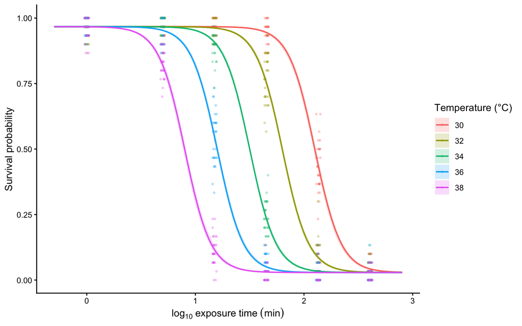

Figure 3: Posterior fitted 4PL curves (solid lines, with shaded 95% credible bands) overlaid on the simulated binomial data (points). One panel-coloured line per assay temperature. Where the fitted curves track the simulated proportions across all five temperatures, the model has recovered the underlying dose-response surface.

### 1.0.4 Deriving $z$ and $CT_{max_{1hr}}$ from the posterior

The whole point of fitting the joint Bayesian 4PL is that the classical TLS quantities — thermal sensitivity ($z$) and the critical thermal limit at a reference duration ($CT_{max_{1hr}}$) — fall out as one-line transformations of the posterior we just fit. We never refit the model; we just push the posterior draws of $(\ell, u, k, \beta_0, \beta_1)$ through the same closed-form expressions used to derive the simulation truth in Step 1.

```r
# Helper: push posterior draws of (ell, u, k, beta0, beta1) through the closed-
# form derivations from the main text to get z and CTmax at 1 hour.
derive_z_ctmax <- function(fit) {
  posterior::as_draws_df(fit) |>      # Pulls out posterior distribution for each parameter from the model as a data frame
    dplyr::mutate(
      z         = -1 / b_mid_T_c,    # Take each draw from the model and calculate a value of z, giving us a poetrior distribution of sensitivity values, z
      alpha     = b_mid_Intercept +
        (1 / b_k_Intercept) *
        log((b_u_Intercept - 0.5) / (0.5 - b_ell_Intercept)) -
        b_mid_T_c * true_params$T_bar,   # Take upper, lower and slope of temp (along with overall mean) to caluclate the intercept.
      CTmax_1hr = (log10(60) - alpha) / b_mid_T_c # Now, use alpha and temperature slope on midpoints, referencing at 1hour, to calculate CTmax
    ) |>
    dplyr::select(z, CTmax_1hr) # Select out the whole posterior distribution for our new derived variables
}

# Now, lets use our function to extract the estimates from these two fitted models.
draws_bin_d <- derive_z_ctmax(fit_bin)
draws_bb_d  <- derive_z_ctmax(fit_bb)
```

Table 3: Posterior medians and 95% credible intervals for thermal sensitivity ($z$) and the critical thermal limit at a 1-hour reference duration ($CT_{max_{1hr}}$), derived directly from the joint Bayesian 4PL fit. Both quantities recover the simulation truth under both binomial and beta-binomial likelihoods.

| quantity | truth | bin_median | bin_lower | bin_upper | bb_median | bb_lower | bb_upper |
| --- | --- | --- | --- | --- | --- | --- | --- |
| z (°C) | 6.667 | 6.668 | 6.550 | 6.798 | 6.783 | 6.475 | 7.121 |
| CTmax at 1 hr (°C) | 32.146 | 32.146 | 32.084 | 32.207 | 32.214 | 32.062 | 32.371 |

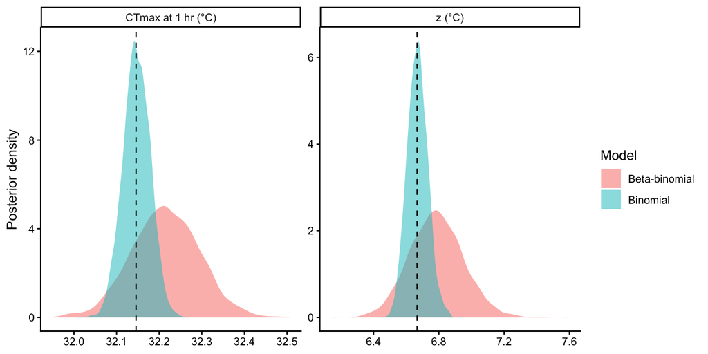

Figure 4: Posterior distributions for thermal sensitivity ($z$) and $CT_{max_{1hr}}$ from the binomial fit (blue) and beta-binomial fit (orange). Vertical dashed lines mark the simulation truth. Both posteriors are tightly concentrated around the truth, illustrating that the joint Bayesian fit recovers the classical TLS quantities with calibrated uncertainty without any additional regression step.

The two derived quantities recover their simulation truth in both fits (Table S 3, Figure S 4), with credible intervals that reflect joint uncertainty in all four 4PL parameters and the temperature slope. Crucially, **we did not run a second regression** to get $z$ and $CT_{max_{1hr}}$. They are properties of the same posterior we already have. This is the key practical advantage of the joint approach over the two-step pipeline: every classical TLS quantity is one transformation away from the fit we have already run, and every quantity inherits the same calibrated uncertainty.

Given that we have the full distribution of $z$ and $CT_{max_{1hr}}$, we can now report on uncertainty in their values *very* easily. All we need to do is take the standard deviation of this distribution for the standard error or we can even summaise with quantiles as follows:

```r
summarise_draws <- function(x) {
  q <- quantile(x, c(0.025, 0.5, 0.975), names = FALSE)
  tibble::tibble(
    mean   = mean(x),
    sd     = sd(x),
    median = q[2],
    lower  = q[1],
    upper  = q[3]
  )
}

uncert_summary <- dplyr::bind_rows(
  summarise_draws(draws_bin_d$z)         |>
    dplyr::mutate(quantity = "z (°C)",             likelihood = "Binomial"),
  summarise_draws(draws_bin_d$CTmax_1hr) |>
    dplyr::mutate(quantity = "CTmax at 1 hr (°C)", likelihood = "Binomial"),
  summarise_draws(draws_bb_d$z)          |>
    dplyr::mutate(quantity = "z (°C)",             likelihood = "Beta-binomial"),
  summarise_draws(draws_bb_d$CTmax_1hr)  |>
    dplyr::mutate(quantity = "CTmax at 1 hr (°C)", likelihood = "Beta-binomial")
) |>
  dplyr::select(quantity, likelihood, mean, sd, median, lower, upper)

# Scalars for inline reporting in the next paragraph.
sd_z_bin  <- round(sd(draws_bin_d$z), 2)
sd_z_bb   <- round(sd(draws_bb_d$z), 2)
sd_ct_bin <- round(sd(draws_bin_d$CTmax_1hr), 2)
sd_ct_bb  <- round(sd(draws_bb_d$CTmax_1hr), 2)
ci_z_bin  <- round(diff(quantile(draws_bin_d$z, c(0.025, 0.975), names = FALSE)), 2)
ci_z_bb   <- round(diff(quantile(draws_bb_d$z, c(0.025, 0.975), names = FALSE)), 2)
ci_ct_bin <- round(diff(quantile(draws_bin_d$CTmax_1hr, c(0.025, 0.975), names = FALSE)), 2)
ci_ct_bb  <- round(diff(quantile(draws_bb_d$CTmax_1hr, c(0.025, 0.975), names = FALSE)), 2)

flextable::flextable(uncert_summary) |>
  flextable::set_header_labels(
    quantity   = "Quantity",
    likelihood = "Likelihood",
    mean       = "Mean",
    sd         = "SD",
    median     = "Median",
    lower      = "2.5%",
    upper      = "97.5%"
  ) |>
  flextable::colformat_double(digits = 3) |>
  flextable::autofit()
```

Table 4: Posterior summaries of $z$ and $CT_{max_{1hr}}$ from the joint Bayesian 4PL: posterior mean, standard deviation, median, and 95% credible interval (2.5% and 97.5% quantiles), reported separately for the binomial and beta-binomial fits.

| Quantity | Likelihood | Mean | SD | Median | 2.5% | 97.5% |
| --- | --- | --- | --- | --- | --- | --- |
| z (°C) | Binomial | 6.669 | 0.063 | 6.668 | 6.550 | 6.798 |
| CTmax at 1 hr (°C) | Binomial | 32.147 | 0.032 | 32.146 | 32.084 | 32.207 |
| z (°C) | Beta-binomial | 6.785 | 0.164 | 6.783 | 6.475 | 7.121 |
| CTmax at 1 hr (°C) | Beta-binomial | 32.214 | 0.079 | 32.214 | 32.062 | 32.371 |

### 1.0.5 Extending the model: smooth or temperature-varying parameters

The closed-form derivations of $z$ and $CT_{max_{1hr}}$ rely on two assumptions:

1. **`mid(T)` is linear in T**, so a single slope $\beta_1$ defines $z = -1/\beta_1$.
2. **$\ell, u$ and $k$ are scalars** (do not depend on $T$), so the asymmetry correction $\tfrac{1}{k}\log\tfrac{u-0.5}{0.5-\ell}$ is a single number rather than a function of temperature.

Both assumptions are convenient but neither is required. Relax either and the framework still works — the closed-form expressions become *functional*, and we recover $z$ and $CT_{max_{1hr}}$ numerically from each posterior draw rather than algebraically. Below we walk through the two practical cases.

#### 1.0.5.1 Case 1 — smooth `mid(T)`

Replacing `mid ~ T_c` in the `bf()` formula with a polynomial (e.g. `mid ~ poly(T_c, 2)`) or a smooth (e.g. `mid ~ s(T_c)`) lets the midpoint shift non-linearly with assay temperature. Keeping $\ell, u, k$ as scalars, the TDT relation becomes

$$\log_{10}\text{LT50}(T) \;=\; \text{mid}(T) \;+\; \tfrac{1}{k}\log\!\tfrac{u - 0.5}{0.5 - \ell},
\tag{3}$$

which is no longer linear in $T$. Two consequences follow:

- **$z$ becomes a function of temperature.** Since $z$ is defined by the local rate of change of $\log_{10}\text{LT50}$ with $T$, $z(T) = -1 \big/ \tfrac{d\,\text{mid}(T)}{dT}$. We either report $z$ at one or more reference temperatures (e.g. the midpoint of the assay range), or as a curve $z(T)$ with credible bands. The classical “single $z$ per species” loses its meaning when the underlying relationship isn’t linear — and when it does, that itself is a useful biological diagnostic.
- **$CT_{max}$ has no closed form.** Solve $\log_{10}\text{LT50}(T) = \log_{10} t_\text{ref}$ for $T$ per posterior draw, e.g. with `uniroot()` over the assay temperature range. The output is the same kind of posterior we already have — produced numerically.

#### 1.0.5.2 Case 2 — temperature affects $\ell$, $u$, or $k$

If any of the shape parameters depends on temperature — for instance `k ~ T_c`, which lets the dose-response steepness change with assay temperature — the asymmetry correction itself becomes a function of $T$:

$$\log_{10}\text{LT50}(T) \;=\; \text{mid}(T) \;+\; \tfrac{1}{k(T)}\log\!\tfrac{u(T) - 0.5}{0.5 - \ell(T)}.
\tag{4}$$

So even if $\text{mid}(T)$ is linear, $\log_{10}\text{LT50}(T)$ is non-linear. The same two consequences as Case 1 apply: $z(T)$ is functional, and $CT_{max}$ requires `uniroot()` per draw.

#### 1.0.5.3 A general numerical recipe

One workflow handles both cases. For each posterior draw $\theta$:

1. Construct a function $\log_{10}\text{LT50}(T \mid \theta)$ using the model’s functional forms for $\text{mid}, \ell, u, k$.
2. Get the **local $z$** at any reference temperature by numerical differentiation: $z(T_\text{ref} \mid \theta) = -1 / \nabla_T \log_{10}\text{LT50}(T_\text{ref} \mid \theta)$.
3. Get **$CT_{max}(t_\text{ref})$** by `uniroot()` of $\log_{10}\text{LT50}(T \mid \theta) - \log_{10} t_\text{ref}$ over the assay temperature range.

Below is a self-contained helper that implements this. As a sanity check we apply it to one posterior draw of `fit_bin` (which used the linear `mid ~ T_c` from earlier) and compare against the closed-form values.

```r
# Generic numerical recovery: pass any function of T (one posterior draw).
recover_tls_numerical <- function(log10_lt50_fn,
                                  T_ref     = NULL,
                                  t_ref_min = 60,
                                  T_search  = c(20, 50)) {
  out <- list()
  if (!is.null(T_ref)) {
    out$z_T <- vapply(T_ref, function(Tval) {
      -1 / numDeriv::grad(log10_lt50_fn, Tval)
    }, numeric(1))
    names(out$z_T) <- T_ref
  }
  out$CTmax_1hr <- tryCatch(
    uniroot(function(T) log10_lt50_fn(T) - log10(t_ref_min),
            interval = T_search)$root,
    error = function(e) NA_real_
  )
  out
}

# For the linear-mid model (this fit), build log10_LT50(T) from one draw.
log10_lt50_from_draw_linear <- function(draw, T_bar) {
  function(T) {
    mid <- draw$b_mid_Intercept + draw$b_mid_T_c * (T - T_bar)
    asym_corr <- (1 / draw$b_k_Intercept) *
      log((draw$b_u_Intercept - 0.5) / (0.5 - draw$b_ell_Intercept))
    mid + asym_corr
  }
}

# Take one random posterior draw and apply the recipe.
set.seed(42)
draws_df  <- posterior::as_draws_df(fit_bin)
one_draw  <- as.list(draws_df[sample.int(nrow(draws_df), 1), ])
fn_linear <- log10_lt50_from_draw_linear(one_draw, T_bar = true_params$T_bar)

result <- recover_tls_numerical(
  fn_linear,
  T_ref     = c(30, 32, 34, 36, 38),
  t_ref_min = 60,
  T_search  = c(25, 45)
)
result
```

```
$z_T
      30       32       34       36       38
6.712102 6.712102 6.712102 6.712102 6.712102

$CTmax_1hr
[1] 32.14023
```

Two things to notice. First, $z(T)$ is constant across the five reference temperatures — as expected, because `mid(T)` is linear in $T$ for this model, so the local slope is the same everywhere. Second, the recovered $CT_{max_{1hr}}$ for this draw matches the closed-form value to within numerical tolerance. This sanity check confirms the recipe; for a fit with smooth or temperature-varying parameters, just swap in a different `log10_lt50_from_draw_*` constructor that respects the new functional form, and run the helper over every posterior draw to get full posteriors of $z(T_\text{ref})$ and $CT_{max_{1hr}}$.

### 1.0.6 Comparing the two pipelines

#### 1.0.6.1 Point-estimate agreement on the same data

Table S 5 puts the two-stage point estimates next to the joint Bayesian posterior medians for both simulated datasets.

Table 5: Point estimates (two-stage) and posterior medians (joint Bayesian) for thermal sensitivity ($z$) and $CT_{max_{1hr}}$, recovered by each of four estimator–dataset combinations from the same simulated datasets. Truth values are the simulation parameters.

| Quantity | Truth | Two-stage (binomial) | Joint Bayesian (binomial) | Two-stage (beta-binomial) | Joint Bayesian (beta-binomial) |
| --- | --- | --- | --- | --- | --- |
| z (°C) | 6.667 | 6.897 | 6.668 | 6.993 | 6.783 |
| CTmax at 1 hr (°C) | 32.146 | 32.004 | 32.146 | 32.137 | 32.214 |

#### 1.0.6.2 Why the joint fit recovers the truth more closely

**Information pooling across temperatures.** The joint 4PL fits a *single* set of asymptotes ($\ell, u$) and a single slope $k$ across all five temperatures, so each temperature’s data anchors all of them. The two-stage’s Stage-1 GLM fits each temperature in isolation, with no constraint shared across temperatures; per-temperature LT50 estimates therefore have higher sampling variance than they need to, and that variance carries through to Stage 2. The joint fit borrows strength across temperatures by construction.

**Asymptote correctness.** The 2PL Stage-1 model forces the asymptotes to 0 and 1. With true asymptotes at $\ell = 0.03$ and $u = 0.97$ the bias is small but non-zero — the Stage-1 LT50 is the temperature at which the *2PL* crosses 0.5, which is not exactly the same as the temperature at which the *4PL* with asymmetric asymptotes crosses 0.5. The joint 4PL estimates $\ell$ and $u$ from the data and so has no analogous bias. The bias grows as the true asymptotes move away from 0 and 1 even further.

**Overdispersion handling.** For the beta-binomial dataset, the joint fit’s beta-binomial likelihood explicitly absorbs the extra-binomial variance into a dispersion parameter ($\phi$). The two-stage’s Stage-1 binomial GLM in its crrent configulation cannot — so per-temperature LT50 estimates are noisier on the beta-binomial dataset than on the binomial one, and that noise propagates into Stage 2. The joint beta-binomial fit removes that noise at its source.

# 2 References

Ørsted, M., Jørgensen, L.B. & Overgaard, J. (2022). [Finding the right thermal limit: A framework to reconcile ecological, physiological and methodological aspects of CTmax in ectotherms](https://doi.org/10.1242/jeb.244514). *Journal of Experimental Biology*, 225, jeb244514.

Rezende, E.L., Castañeda, L.E. & Santos, M. (2014). [Tolerance landscapes in thermal ecology](https://doi.org/10.1111/1365-2435.12268). *Functional Ecology*, 28, 799–809.

# 3 Session Information

**R version 4.5.3 (2026-03-11)**

**Platform:** aarch64-apple-darwin20

**locale:** C.UTF-8||C.UTF-8||C.UTF-8||C||C.UTF-8||C.UTF-8

**attached base packages:** *stats*, *graphics*, *grDevices*, *utils*, *datasets*, *methods* and *base*

**other attached packages:** *pander(v.0.6.6)*, *flextable(v.0.9.9)*, *tidybayes(v.3.0.7)*, *posterior(v.1.6.1)*, *brms(v.2.23.0)*, *Rcpp(v.1.1.1-1.1)*, *ggplot2(v.4.0.3)*, *purrr(v.1.2.2)*, *tibble(v.3.3.1)*, *tidyr(v.1.3.2)*, *dplyr(v.1.2.1)* and *here(v.1.0.1)*

**loaded via a namespace (and not attached):** *svUnit(v.1.0.8)*, *tidyselect(v.1.2.1)*, *farver(v.2.1.2)*, *loo(v.2.9.0)*, *S7(v.0.2.2)*, *fastmap(v.1.2.0)*, *TH.data(v.1.1-3)*, *tensorA(v.0.36.2.1)*, *pacman(v.0.5.1)*, *fontquiver(v.0.2.1)*, *digest(v.0.6.39)*, *estimability(v.1.5.1)*, *lifecycle(v.1.0.5)*, *survival(v.3.8-6)*, *magrittr(v.2.0.5)*, *compiler(v.4.5.3)*, *rlang(v.1.2.0)*, *tools(v.4.5.3)*, *yaml(v.2.3.12)*, *data.table(v.1.18.2.1)*, *knitr(v.1.51)*, *askpass(v.1.2.1)*, *bridgesampling(v.1.2-1)*, *htmlwidgets(v.1.6.4)*, *curl(v.7.1.0)*, *xml2(v.1.5.2)*, *RColorBrewer(v.1.1-3)*, *multcomp(v.1.4-28)*, *abind(v.1.4-8)*, *withr(v.3.0.2)*, *grid(v.4.5.3)*, *gdtools(v.0.4.2)*, *xtable(v.1.8-8)*, *emmeans(v.2.0.3)*, *scales(v.1.4.0)*, *MASS(v.7.3-65)*, *cli(v.3.6.6)*, *mvtnorm(v.1.3-7)*, *rmarkdown(v.2.31)*, *ragg(v.1.5.2)*, *generics(v.0.1.4)*, *otel(v.0.2.0)*, *RcppParallel(v.5.1.11-2)*, *katex(v.1.5.0)*, *stringr(v.1.6.0)*, *splines(v.4.5.3)*, *bayesplot(v.1.15.0)*, *parallel(v.4.5.3)*, *matrixStats(v.1.5.0)*, *vctrs(v.0.7.3)*, *V8(v.6.0.4)*, *Matrix(v.1.7-4)*, *sandwich(v.3.1-1)*, *jsonlite(v.2.0.0)*, *fontBitstreamVera(v.0.1.1)*, *arrayhelpers(v.1.1-0)*, *systemfonts(v.1.3.2)*, *xslt(v.1.5.1)*, *ggdist(v.3.3.3)*, *glue(v.1.8.1)*, *equatags(v.0.2.1)*, *codetools(v.0.2-20)*, *distributional(v.0.6.0)*, *stringi(v.1.8.7)*, *gtable(v.0.3.6)*, *pillar(v.1.11.1)*, *htmltools(v.0.5.9)*, *Brobdingnag(v.1.2-9)*, *openssl(v.2.4.0)*, *R6(v.2.6.1)*, *textshaping(v.1.0.5)*, *rprojroot(v.2.1.1)*, *evaluate(v.1.0.5)*, *lattice(v.0.22-9)*, *backports(v.1.5.1)*, *fontLiberation(v.0.1.0)*, *rstantools(v.2.6.0)*, *zip(v.2.3.3)*, *uuid(v.1.2-2)*, *coda(v.0.19-4.1)*, *nlme(v.3.1-168)*, *checkmate(v.2.3.4)*, *officer(v.0.6.10)*, *xfun(v.0.57)*, *zoo(v.1.8-14)* and *pkgconfig(v.2.0.3)*